# ¶ MEDBS datacall Report ¶

Compiled on 03/07/2023, 14:43

No catch data available

No Landing data available

# 1 Discard table

## 1.1 Presence of duplicated records

Data included in the discard table were checked for the presence of duplicated records. The result of the check is here reported:

- No replicated records in Discard data

## 1.2 Presence of disaggregated records

Data included in the discards table were checked for the presence of disaggregated records. The result of the check is here reported:

- No disaggregated records in discards data

## 1.3 Coverage of discards data

### 1.3.1 GSA 18

#### 1.3.1.1 DPS

*Coverage of discard data for DPS in GSA 18*

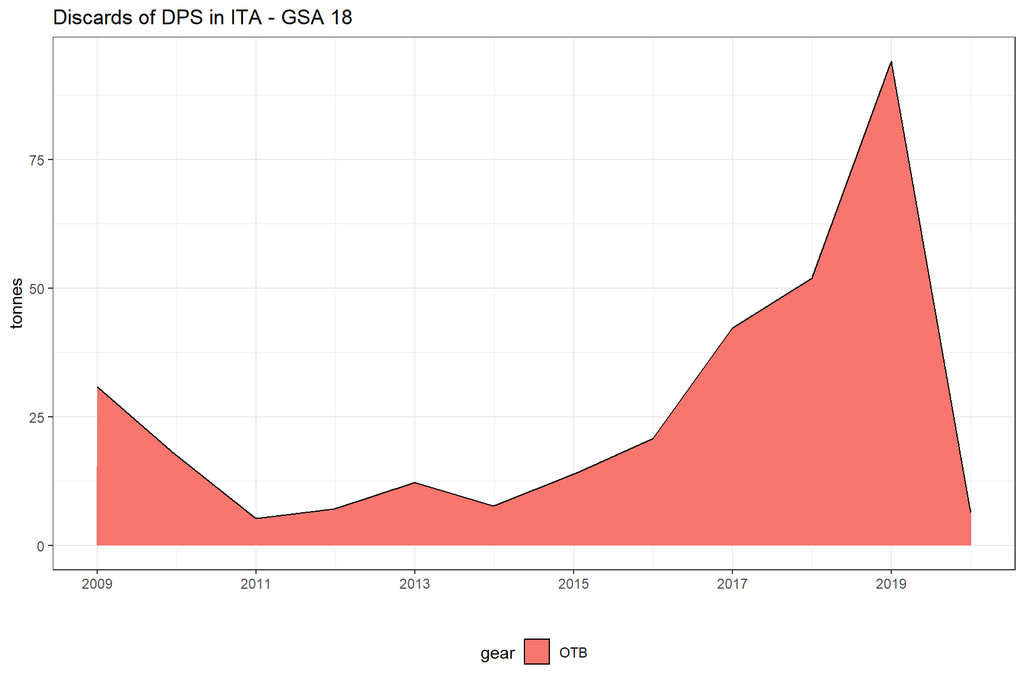

## 1.6 Mean weight by year, gear and fishery aggregation

Discard data were checked to assess the consistency of mean species discard weight by year, gear and fishery.

### 1.6.1 GSA 18

#### 1.6.1.1 DPS

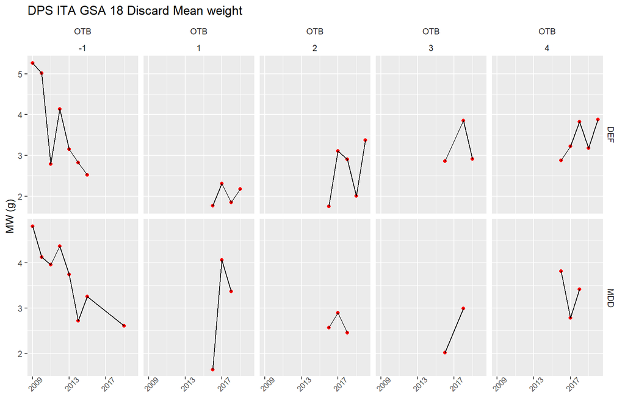

## 1.7 Kolmogorov-Smirnov test

The Kolmogorov-Smirnov test provides cumulative length distribution plots by fishery and year. The test is performed on couples of years to assess if their distributions belong to the same population. The summary table reports only the cases in which the distribution does not belong to the same population in the given comparison.

### 1.7.1 GSA 18

#### 1.7.1.1 DPS

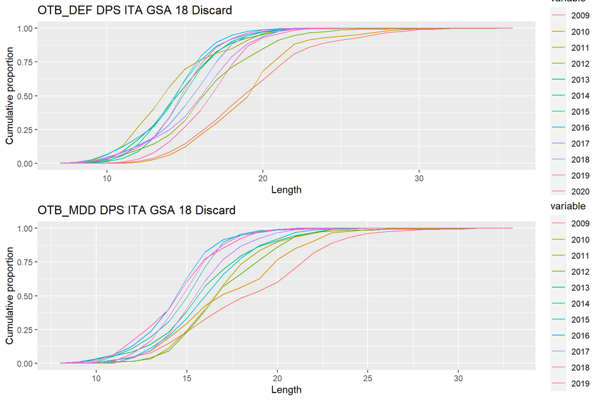

Plot of cumulative length distributions by fishery and year for DPS - ITA - GSA 18

[figure not shown]

## 1.8 Check the presence of length classes numbers with zeros in discards

The presence of length classes numbers zero with having weigth > 0 in discards are reported in the following table:

### 1.8.1 GSA 18

#### 1.8.1.1 DPS

- No discard records with 0 length class values having weigth > 0 for : DPS - ITA - GSA 18

## 1.9 Main length size indicators

The time series of the main length size indicators (mean and median length) by fishery was estimated and hereafter reported:

### 1.9.1 GSA 18

#### 1.9.1.1 DPS

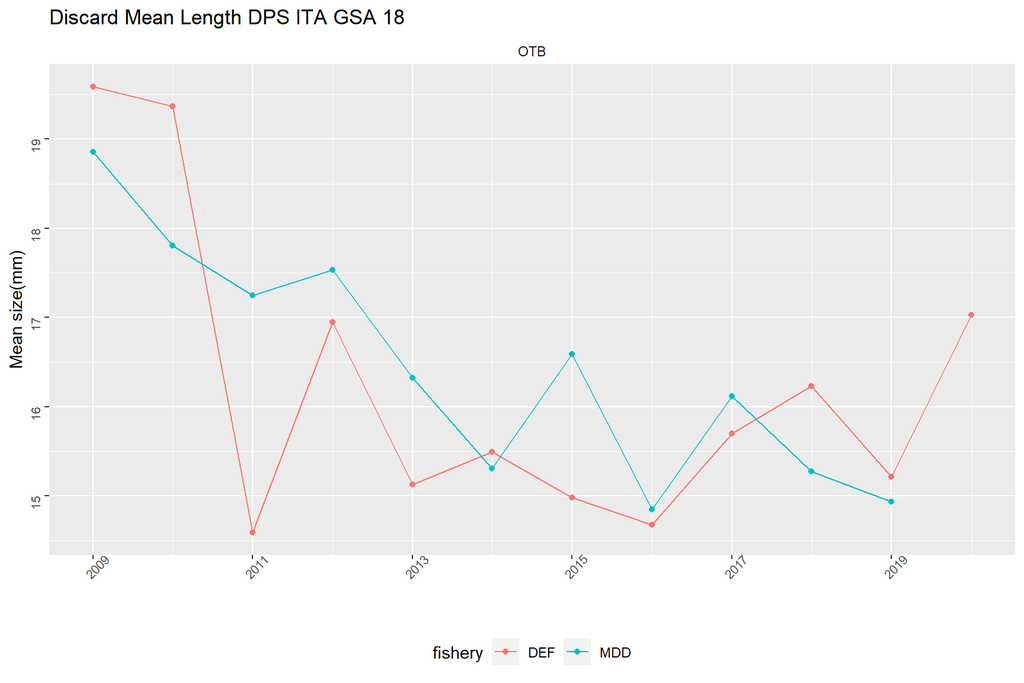

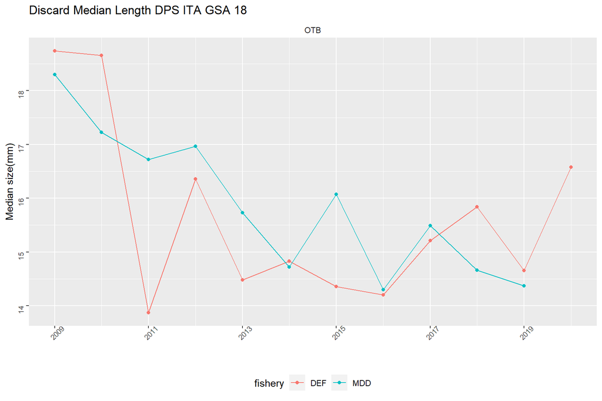

## 1.10 Check the presence of years with missing length distribution

Discard data were checked to identify the presence of years with missing length distributions. The years with the missing length distribution are reported in the following table (if any):

### 1.10.1 GSA 18

#### 1.10.1.1 DPS

- No years in discards with missing length distribution for : DPS - ITA - GSA 18

## 1.11 Check the presence of discard weights with zeros in discards

The presence of rows in discards with 0 values in weights having length classes filled in is reported in the following table:

### 1.11.1 GSA 18

#### 1.11.1.1 DPS

- No Discard records in weight equal to 0 having length classes filled in for : DPS - ITA - GSA 18

## 1.12 Check the presence of discard weights with -1 in discards

The presence of rows in discards with -1 values in weights having length classes filled in is reported in the following table:

### 1.12.1 GSA 18

#### 1.12.1.1 DPS

- No discard records in weight equal to -1 having length classes filled in for : DPS - ITA - GSA 18

## 1.13 Total discard time series by quarter

To identify possible inconsistencies in discard data, the species time series of discard volumes is here plotted by quarter.

### 1.13.1 GSA 18

#### 1.13.1.1 DPS

Plot of total discards for DPS - ITA - GSA 18

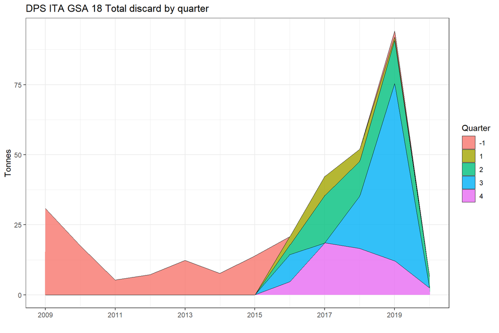

## 1.14 Total discard time series by gear and fishery

To identify possible inconsistencies in discard data, the species time series of discard volumes is here plotted by fishery and gear.

### 1.14.1 GSA 18

#### 1.14.1.1 DPS

Plot of total discards for DPS - ITA - GSA 18

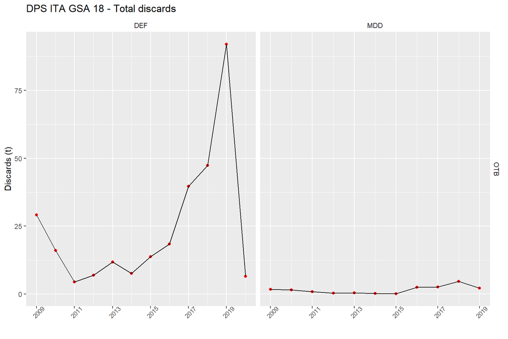

## 1.15 Discard Length Frequency Distribution

To identify possible inconsistencies in discards lengths structure, the species’ LFDs are here plotted by fishery and year

### 1.15.1 GSA 18

#### 1.15.1.1 DPS

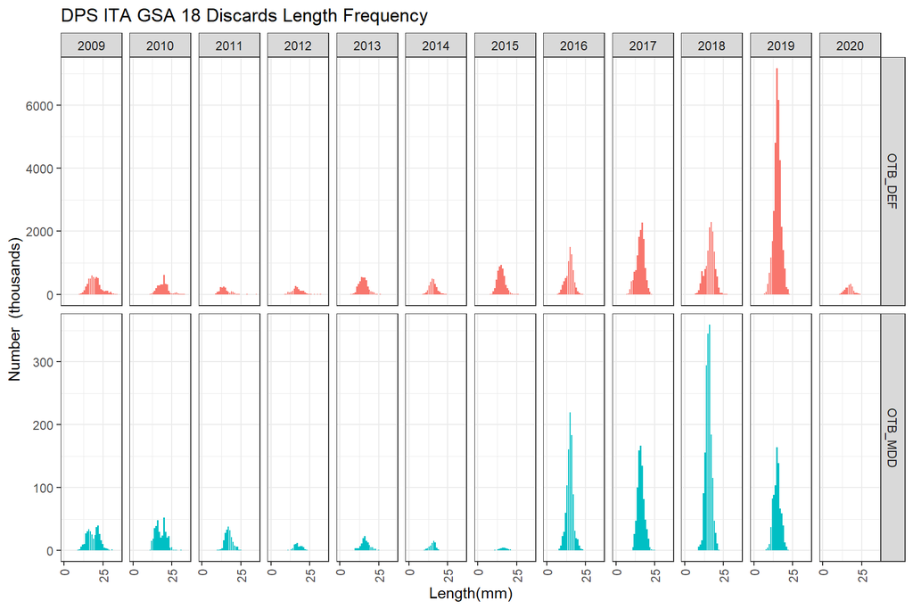

*Plot of total discards for DPS in GSA 18*

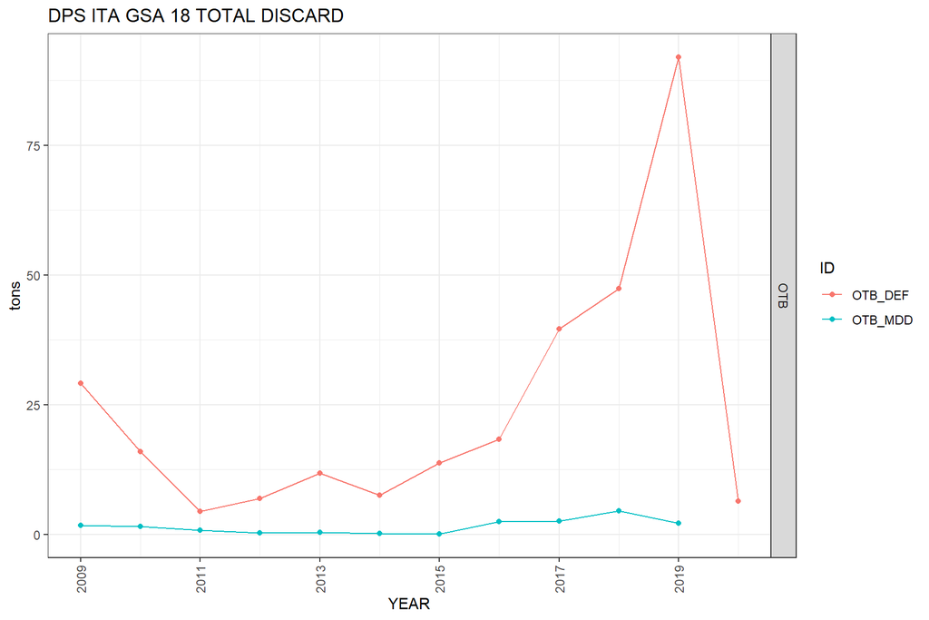

No growth parameters (GP) data available

No Maturity at Age (MA) data available

No Maturity at Length (ML) data available

No Sex Ratio at age (SRA) data available

No Sex Ratio at length (SRL) data available

No Age-Length Keys (ALK) data available